# Introduction

## Nice to meet you

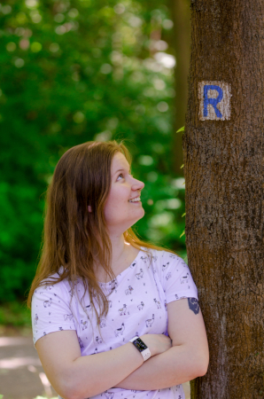

- Juli Tkotz
- PhD student at the Central Institute of Mental Health, Mannheim
- RG Psychology and Neurobiology of Sleep and Memory
- I like R

## Orga stuff

- Workshop timing etc.
- Breaks?
- Anything else?

## I REALLY like R

[figure not shown]

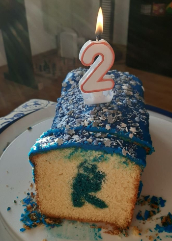

## I REALLY like R

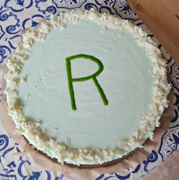

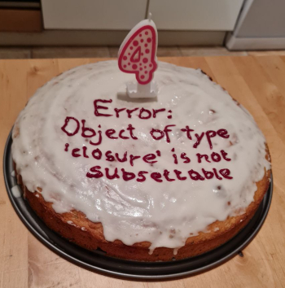

## About R

[figure not shown]

- Popular programming language for data science and statistics.
- Data wrangling, analysis and visualisation.
- But also manuscripts, presentations (like this one), web apps …

[figure not shown]

## R is quirky

[figure not shown]

@JonTheGeek - https://twitter.com/juli_tkotz/status/1363236862094172162

- R is open source, with tons of additional packages that are developing rapidly.
- Managing your “dependencies” can be a bit overwhelming.
- Embrace the quirkiness :-)

## What can you expect?

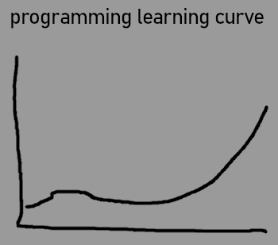

- You can’t learn a language in 2 days.
- **But** you will acquire the basic skills for the journey ahead.
- Learning is only possible by doing. **No excuses: Start. Using. Code. Now!**

## Coding is good for you

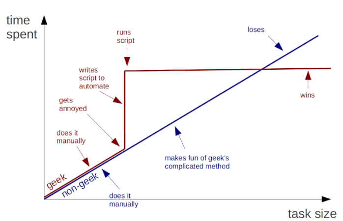

- Eventually saves time and reduces copy-paste mistakes.
- Key to reproducible science.

## Googling is okay

[figure not shown]

- You don’t need to know how to do it - but you need to know where to look.
- Googling, browsing Stack Overflow etc. will be part of your workflow.

Who are you?

- What you do.
- Your experience with `R`.
- Your expectations for this course.
- Your favourite cake.